## Generating simulated data

The true model in this case is a logistic regression model.

Check: Can you understand the true data generating process by reading the code?

```r
# Setting parameters
set.seed(1)
# Try changing some parameters
n <- 500
p <- 4
sparsity <- 2
nonzero_beta <-
  rep(1, sparsity) # or e.g. runif(sparsity, min = -1, max = 1)
true_beta <- c(nonzero_beta, rep(0, p - sparsity))
class_shift <- 2.5 # change this
```

The |> operator is called the pipe operator. It allows you to pass the output of one function directly as the input to another function in a more readable and streamlined way. It is similar in functionality to the %>% operator.

select(y, num_range(“x.”, 1:4)): select columns with names that contain the prefix “x.” followed by a number within a specified range.

Purpose of class_shift: control the balance of the classes. Larger shift leads to larger mu, then leads to higher proportion of positive class (class 1).

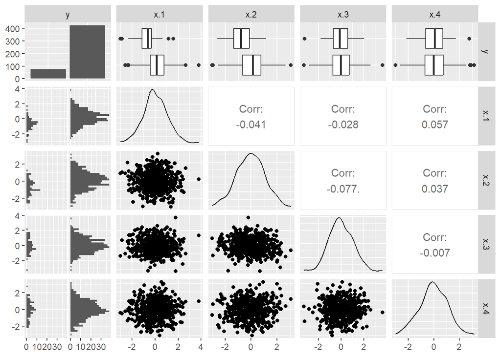

```r
# Generating simulated data
X <- matrix(rnorm(n*p), nrow = n)
mu <- class_shift + X %*% true_beta  #z = XW+b
px <- exp(mu)/(1+exp(mu))
Y <- rbinom(n, 1, prob = px)
train_ld <- data.frame(y = as.factor(Y), x = X)
train_ld |>
  select(y, num_range("x.", 1:4)) |>
  ggpairs(progress = F)
```

Check: Do these plots fit with your understanding of the true data generating process?

```r
# Class (im)balance
table(train_ld$y)
```

```
##
##   0   1
##  74 426
```

```r
train_ld |> count(y)
```

```
##   y   n
## 1 0  74
## 2 1 426
```

**Question**: What would the accuracy be for a classifier that always predicts the most common class?

```r
const_yhat_success <- mean(train_ld$y == 1)
max(const_yhat_success, 1 - const_yhat_success) # this equals to 426/500=0.852, but only on training data, meaningless.
```

```
## [1] 0.852
```

## Logistic regression model

### Coefficients

```r
c(class_shift, true_beta)
```

```
## [1] 2.5 1.0 1.0 0.0 0.0
```

```r
fit_glm <- glm(y ~ ., family = binomial(), data = train_ld)
fit_glm
```

```
##
## Call:  glm(formula = y ~ ., family = binomial(), data = train_ld)
##
## Coefficients:
## (Intercept)          x.1          x.2          x.3          x.4
##     2.48089      1.19239      1.04222      0.11820     -0.04386
##
## Degrees of Freedom: 499 Total (i.e. Null);  495 Residual
## Null Deviance:       419.2
## Residual Deviance: 317.6     AIC: 327.6
```

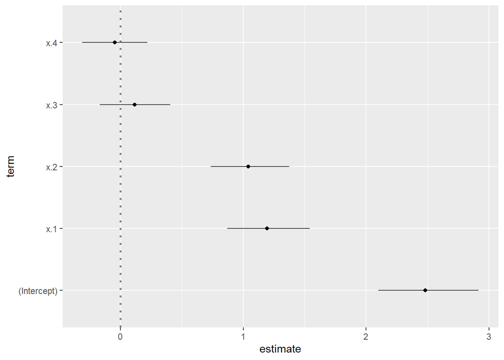

```r
fit_glm |> ggcoef()
```

Coefficients on the odds scale:

The coefficients from the glm model are the coefficients of the logits, which is exponential of the odds. We can the exponential of the coefficients such that we can observe how they change odds. For example, $\beta_1=1.19$, this means we increase x1 by one unit, logits $\log(\frac{p}{1-p})$ will increase by 1.19. In the following coefficient for x1 is 3.29, which means we increase x1 by one unit, odds ratio will be 3.29 greater.

```r
fit_glm <- glm(y ~ ., family = binomial(), data = train_ld)
fit_glm |>
  tidy(exponentiate = TRUE) |> knitr::kable()
```

| term | estimate | std.error | statistic | p.value |
| --- | --- | --- | --- | --- |
| (Intercept) | 11.9518723 | 0.2067843 | 11.9974661 | 0.0000000 |
| x.1 | 3.2949620 | 0.1704925 | 6.9938266 | 0.0000000 |
| x.2 | 2.8355109 | 0.1622098 | 6.4251500 | 0.0000000 |
| x.3 | 1.1254655 | 0.1456378 | 0.8115803 | 0.4170325 |
| x.4 | 0.9570916 | 0.1344844 | -0.3261060 | 0.7443442 |

### Predictions

```r
fit_glm_predictions <- augment(fit_glm, type.predict = "response")
fit_glm_predictions |> pull(.fitted) |> mean() #take out the column named .fitted and calculate the mean.
```

```
## [1] 0.852
```

```r
mean(fit_glm_predictions$.fitted)
```

```
## [1] 0.852
```

**Question**: Does this number look familiar? Why?

**Answer**: It’s the proportion of the majority class that we saw before. Any other value here would indicate an overall bias in the predictions of the model.

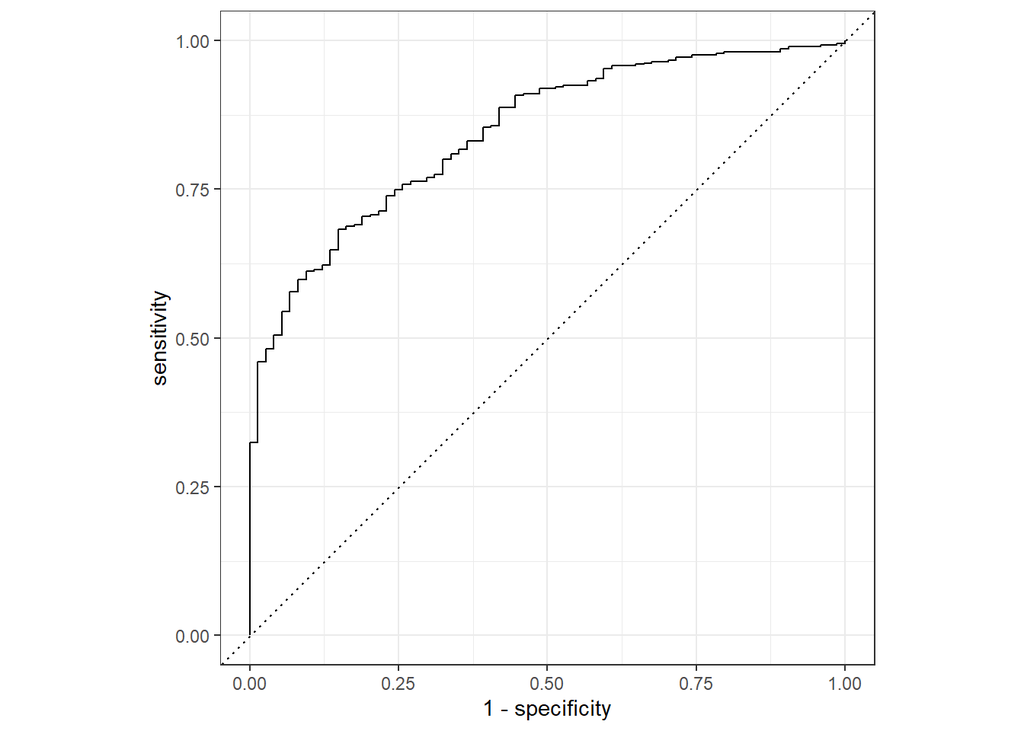

```r
# Note: the event_level option is currently required because
# of a mismatch between glm() and yardstick
fit_glm_predictions |>
  roc_curve(truth = y, .fitted,
            event_level = "second") |>
  autoplot()
```

ROC curve: TPR against FPR, consisting of choosing different levels of threshold. At (0,0), the threshold is 1, which means we choose all to be negative, hence TPR=FPR=0; At (1,1), the threshold is 0, which means we vote all positive, then TPR=FPR=1.

**Note**: When a classification model outputs class probabilities or numeric scores these can be converted into classifications by setting thresholds or cutoffs. If we keep the model fixed but change the cutoff, we can achieve different trade-offs between false positives and false negatives (or specificity and sensitivity, precision and recall, etc–these are just other names). Plots like this `roc_curve` (see also `?pr_curve`) show all the possible trade-off values for one model.

**Question**: Using curves like this how can we compare different models? Give at least two suggestions.

**Answer**: We could compare at a specific point on the curve, for example if that point corresponds to a certain false positive rate that has some practical or domain-specific importance (e.g. regulations). Or we could compute the area under the curves, e.g. using the `roc_auc` function.

Classify at several different thresholds

```r
# Note: true and predicted classes must use same
# label names, hence the factor(as.numeric())
higher_cutoff <- const_yhat_success + .05
confusion_matrix_higher <-
  fit_glm_predictions |>
  mutate(yhat = factor(as.numeric(.fitted > higher_cutoff))) |>
  conf_mat(truth = y, estimate = yhat)
```

```r
lower_cutoff <- .2
confusion_matrix_lower <-
  fit_glm_predictions |>
  mutate(yhat = factor(as.numeric(.fitted > lower_cutoff))) |>
  conf_mat(truth = y, estimate = yhat)
```

```r
confusion_matrix_higher
```

```
##           Truth
## Prediction   0   1
##          0  65 164
##          1   9 262
```

```r
confusion_matrix_lower
```

```
##           Truth
## Prediction   0   1
##          0   0   2
##          1  74 424
```

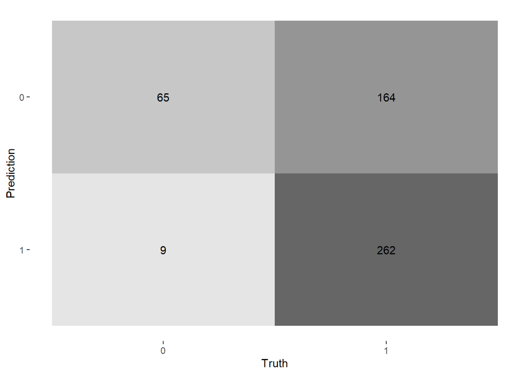

```r
confusion_matrix_higher |> autoplot(type = "heatmap")
```

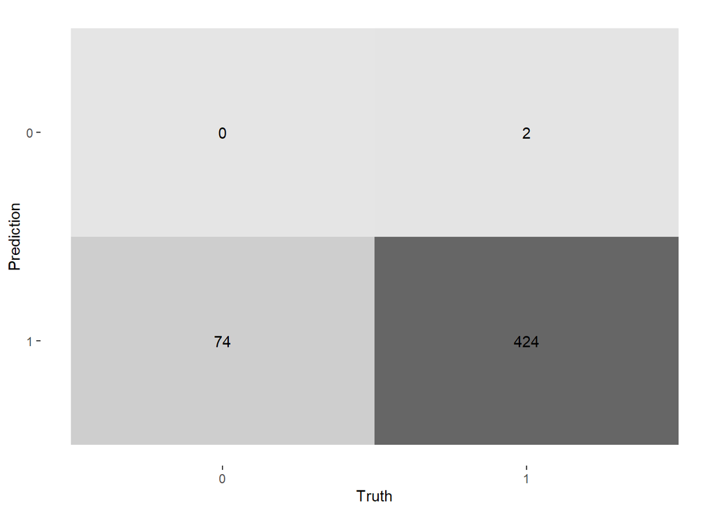

```r
confusion_matrix_lower |> autoplot(type = "heatmap") #almost all predictions are positive
```

Comparing across various metrics:

```r
higher_summary <- summary(confusion_matrix_higher) |>
  mutate(higher = .estimate) |>
  select(.metric, higher)
lower_summary <- summary(confusion_matrix_lower) |>
  mutate(lower = .estimate) |>
  select(lower)
cbind(higher_summary, lower_summary) |>
  knitr::kable()
```

| .metric | higher | lower |
| --- | --- | --- |
| accuracy | 0.6540000 | 0.8480000 |
| kap | 0.2645058 | -0.0078506 |
| sens | 0.8783784 | 0.0000000 |
| spec | 0.6150235 | 0.9953052 |
| ppv | 0.2838428 | 0.0000000 |
| npv | 0.9667897 | 0.8514056 |
| mcc | 0.3516568 | -0.0264126 |
| j_index | 0.4934019 | -0.0046948 |
| bal_accuracy | 0.7467009 | 0.4976526 |
| detection_prevalence | 0.4580000 | 0.0040000 |
| precision | 0.2838428 | 0.0000000 |
| recall | 0.8783784 | 0.0000000 |
| f_meas | 0.4290429 | 0.0000000 |

Accuracy benefits from a lower threshold, since the data is very imbalanced toward positive class. So a lower threshold will vote toward the positive class.

Note the `accuracy`, for example, which is the proportion of data where the predicted class and true class are equal.

### Sub-sampling for class balance

choose the number of positive samples to be the same as negative samples

```r
rare_class_size <- min(table(train_ld$y))
train_subsampled <- train_ld |>
  group_by(y) |>
  sample_n(rare_class_size) |>
  ungroup()

fit_glm_subs <- glm(y ~ ., family = binomial(), data = train_subsampled)
```

Does this change coefficients or inferences about them?

```r
cbind(
  tidy(fit_glm) |> select(term, estimate, std.error),
  tidy(fit_glm_subs) |> select(estimate, std.error)) |>
  knitr::kable()
```

| term | estimate | std.error | estimate | std.error |
| --- | --- | --- | --- | --- |
| (Intercept) | 2.4808879 | 0.2067843 | 0.8869130 | 0.2734060 |
| x.1 | 1.1923946 | 0.1704925 | 1.6250092 | 0.2957344 |
| x.2 | 1.0422221 | 0.1622098 | 1.1683666 | 0.2551454 |
| x.3 | 0.1181967 | 0.1456378 | 0.2936595 | 0.2475284 |
| x.4 | -0.0438562 | 0.1344844 | 0.0915651 | 0.1980801 |

```r
fit_glm
```

```
##
## Call:  glm(formula = y ~ ., family = binomial(), data = train_ld)
##
## Coefficients:
## (Intercept)          x.1          x.2          x.3          x.4
##     2.48089      1.19239      1.04222      0.11820     -0.04386
##
## Degrees of Freedom: 499 Total (i.e. Null);  495 Residual
## Null Deviance:       419.2
## Residual Deviance: 317.6     AIC: 327.6
```

```r
fit_glm_subs
```

```
##
## Call:  glm(formula = y ~ ., family = binomial(), data = train_subsampled)
##
## Coefficients:
## (Intercept)          x.1          x.2          x.3          x.4
##     0.88691      1.62501      1.16837      0.29366      0.09157
##
## Degrees of Freedom: 147 Total (i.e. Null);  143 Residual
## Null Deviance:       205.2
## Residual Deviance: 135.2     AIC: 145.2
```

**Note**: With a smaller sample size, the balanced training data gives us larger `std.errors` for our estimates. (Wider confident intervals, larger p-values).

```r
fit_glm_subs_predictions <- augment(fit_glm_subs, type.predict = "response")
fit_glm_subs_predictions |> pull(.fitted) |> mean()
```

```
## [1] 0.5
```

Training data classes are balanced so the predictions are also balanced.

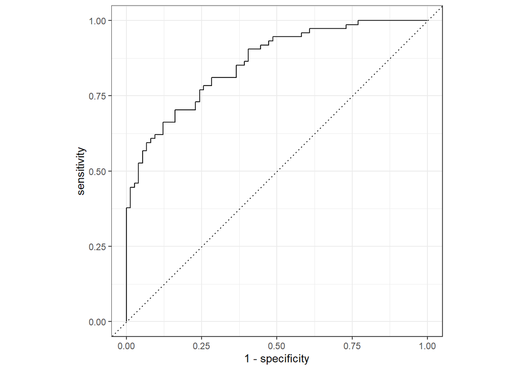

```r
# Note: the event_level option is currently required because
# of a mismatch between glm() and yardstick
fit_glm_subs_predictions |>
  roc_curve(truth = y, .fitted,
            event_level = "second") |>
  autoplot()
```

Classify at several different thresholds

```r
# Note: true and predicted classes must use same
# label names, hence the factor(as.numeric())
higher_cutoff <- const_yhat_success + .05
confusion_matrix_subs_higher <-
  fit_glm_subs_predictions |>
  mutate(yhat = factor(as.numeric(.fitted > higher_cutoff))) |>
  conf_mat(truth = y, estimate = yhat)
```

```r
lower_cutoff <- .2
confusion_matrix_subs_lower <-
  fit_glm_subs_predictions |>
  mutate(yhat = factor(as.numeric(.fitted > lower_cutoff))) |>
  conf_mat(truth = y, estimate = yhat)
```

```r
confusion_matrix_subs_higher
```

```
##           Truth
## Prediction  0  1
##          0 74 48
##          1  0 26
```

```r
confusion_matrix_subs_lower
```

```
##           Truth
## Prediction  0  1
##          0 35  4
##          1 39 70
```

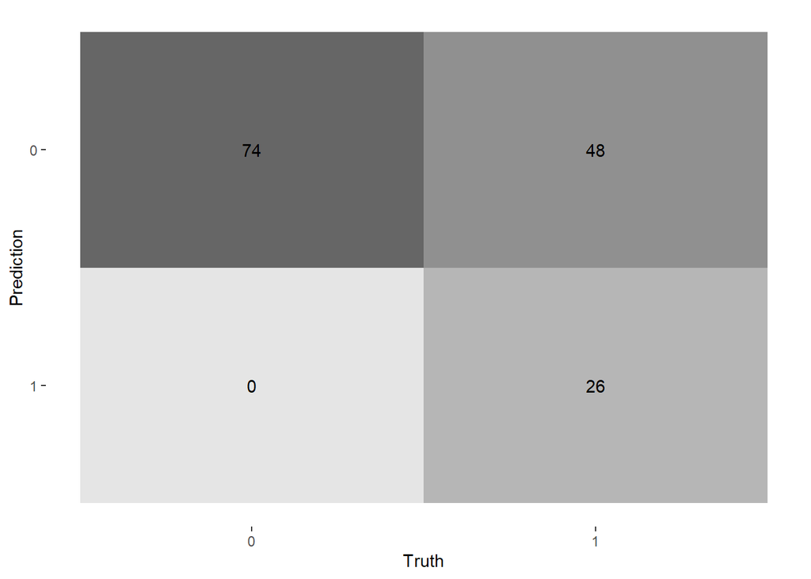

```r
confusion_matrix_subs_higher |> autoplot(type = "heatmap")
```

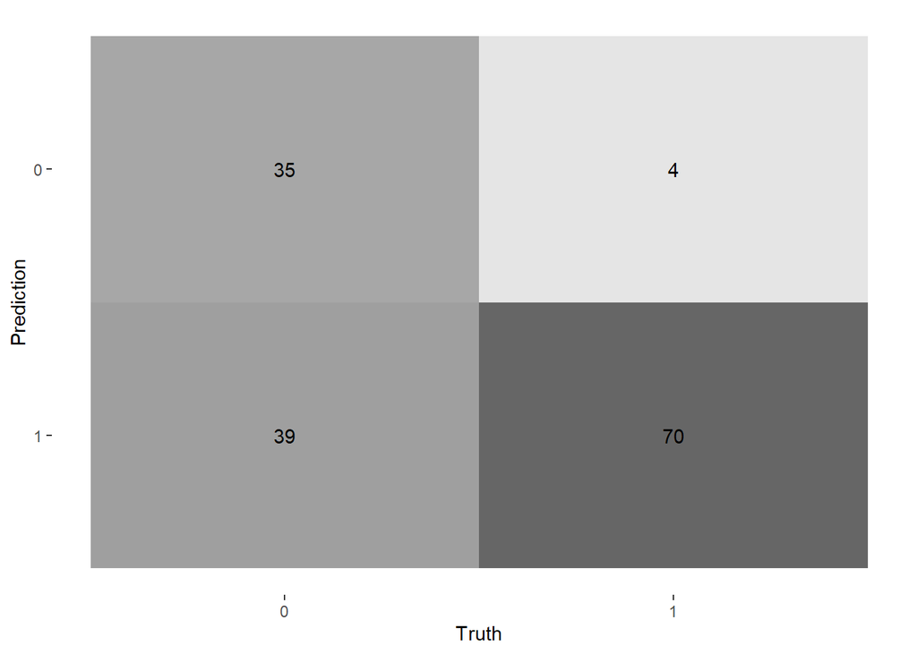

```r
confusion_matrix_subs_lower |> autoplot(type = "heatmap")
```

Comparing across various metrics:

```r
higher_subs_summary <- summary(confusion_matrix_subs_higher) |>
  mutate(higher = .estimate) |>
  select(.metric, higher)
lower_subs_summary <- summary(confusion_matrix_subs_lower) |>
  mutate(lower = .estimate) |>
  select(lower)
metrics <- c("accuracy", "bal_accuracy") #, "precision", "recall")
rbind(
cbind(higher_summary, lower_summary) |>
  filter(.metric %in% metrics) |>
  mutate(subsampled = FALSE),
cbind(higher_subs_summary, lower_subs_summary) |>
  filter(.metric %in% metrics) |>
  mutate(subsampled = TRUE)) |>
  knitr::kable()
```

| .metric | higher | lower | subsampled |
| --- | --- | --- | --- |
| accuracy | 0.6540000 | 0.8480000 | FALSE |
| bal_accuracy | 0.7467009 | 0.4976526 | FALSE |
| accuracy | 0.6756757 | 0.7094595 | TRUE |
| bal_accuracy | 0.6756757 | 0.7094595 | TRUE |

**Question**: Suppose we have trained a model on data that was subsampled to create class balance. Then we choose classification cutoffs to achieve a desired trade-off between precision/recall (or false positives and false negatives), and we do this still while using the subsampled training data. What will happen if we start using that model to classify data from a new or full dataset that hasn’t been subsampled? **Answer**: Predictions on imbalanced data will achieve a different trade-off between false positives and false negatives. To calibrate this we would need to choose a different classification threshold that works on imbalanced data.

In a word: What if we train on a balanced dataset and predict on an imbalanced dataset? Answer: adjust the threshold according to the dominating class. If positive class dominates, increase the threshold; otherwise decrease the threshold. Or we can use some other metrics which are not so sensitive to the class imbalance, such as F1 score or balanced accuracy.

# 1. Sigmoid Function

The logistic function, also known as the **sigmoid function**, is used to model the relationship between input features and the probability of the positive class:

$$\sigma(z) = \frac{1}{1 + e^{-z}}$$

where $z$ is the linear combination of the input features:

$$z = \mathbf{w}^T \mathbf{x}$$

- $\mathbf{w}$: Weights of the model.
- $\mathbf{x}$: Feature vector.

The output of the logistic function is a value between **0 and 1**, representing the predicted probability of the positive class.

# 2. Log-Odds and Linear Relationship

The **log-odds** (or **logit**) is the logarithm of the odds of the positive class. In logistic regression, the log-odds is modeled as a linear function of the input features:

$$\text{logit}(p) = \log\left( \frac{p}{1 - p} \right) = \mathbf{w}^T
\mathbf{x}$$

where $p$ is the predicted probability of the positive class.

# 3. Cost Function and Maximum Likelihood Estimation

The goal of logistic regression is to find the optimal parameters (weights and bias) that minimize the prediction error. Instead of using **Mean Squared Error**, logistic regression uses the **logistic loss** or **cross-entropy loss** function, which is defined as:

$$C(\mathbf{w}) = -\frac{1}{m} \sum_{i=1}^m \left[ y^{(i)}
\log(\hat{y}^{(i)}) + (1 - y^{(i)}) \log(1 - \hat{y}^{(i)}) \right]$$

The cost function represents the **negative log-likelihood** of the data given the model parameters.

# 4. Maximum Likelihood Derivation

To estimate the parameters, we use **Maximum Likelihood Estimation (MLE)**. The likelihood function for logistic regression is:

$$L(\mathbf{w}) = \prod_{i=1}^m \left( \hat{y}^{(i)} \right)^{y^{(i)}}
\left( 1 - \hat{y}^{(i)} \right)^{1 - y^{(i)}}$$

The **log-likelihood** is obtained by taking the logarithm of the likelihood function:

$$\ell(\mathbf{w}) = \sum_{i=1}^m \left[ y^{(i)} \log(\hat{y}^{(i)}) + (1
- y^{(i)}) \log(1 - \hat{y}^{(i)}) \right]$$

The **negative log-likelihood** is equivalent to the cost function, which we aim to minimize.

Question: why there may be problems for logistic regression in a well-classified data?

the log-likelihood function is maximized when the predicted probabilities approach 0 or 1 for all data points, which is only possible if the coefficients approach infinity. Have a look at the log-likelihood function, it is maximized either when $\hat y=0$ or $\hat y=1$. The predicted probability is
$$P(\hat y =1) =\frac{1}{1 + e^{-(\mathbf{w}^T \mathbf{x})}}$$
Hence to maximize the log-likelihood, the optimization process will drive $P(\hat y =1)$ to be 0 or 1. And this will drive $\mathbf{w}$ to be negative or positive infinity.

# 5. Gradient Descent

**Gradient descent** is an iterative optimization algorithm used to minimize the cost function. The process is as follows:

1. **Initialize Parameters**: Start with random values for the weights $\mathbf{w}$ and bias $b$.
2. **Compute Predictions**: For each training example, compute the predicted probability:

   $$\hat{y}^{(i)} = \sigma(\mathbf{w}^T \mathbf{x}^{(i)})$$
3. **Compute Cost**: Calculate the cost function $C(\mathbf{w})$.
4. **Compute Gradients**: Calculate the gradients of the cost function with respect to the weights and bias:
   - For the weights $\mathbf{w}$:

     $$\frac{\partial C(\mathbf{w})}{\partial w_j} = \frac{1}{m} \sum_{i=1}^m
     \left( \hat{y}^{(i)} - y^{(i)} \right) x_j^{(i)}, \quad \text{for } j =
     1, 2, \dots, n$$
5. **Update Parameters**: Update the weights and bias using a learning rate $\alpha$:

   $$\mathbf{w} := \mathbf{w} - \alpha \frac{\partial C(\mathbf{w})}{\partial
   \mathbf{w}}$$
6. **Repeat**: Repeat steps 2-5 until the cost function converges to a minimum.

# 6. Hessian Matrix and Newton’s Method

An alternative optimization method is **Newton’s Method**, which uses the **Hessian matrix** to find the minimum of the cost function. The **Hessian matrix** for logistic regression is given by:

$$H = \frac{1}{m} \sum_{i=1}^m \hat{y}^{(i)} (1 - \hat{y}^{(i)})
\mathbf{x}^{(i)} \mathbf{x}^{(i)T}$$

The parameter update rule for Newton’s method is:

$$\theta := \theta - H^{-1} \nabla J(\theta)$$

where $\theta = [\mathbf{w}, b]$ is the vector of parameters, and $\nabla J(\theta)$ is the gradient of the cost function.

# SVM

The primal optimization problem for SVM aims to find a weight vector (**w**) and bias (**b**) that maximize the margin between classes while correctly classifying all training points. The problem is to optimize:
$$\max_{\mathbf{w}, b} [\min_{i}
\frac{\mathbf{w}^Tx_i+b}{||\mathbf{w}||}],~~s.t~~~y_i(\mathbf{w}^Tx_i+b)>0$$

Now let
$$M = \min_{i}
\frac{\mathbf{w}^Tx_i+b}{||\mathbf{w}||}$$
be the margin the optimization becomes
$$\max_{\mathbf{w}, b,M} M, ~~~s.t~
\frac{y_i(\mathbf{w}^Tx_i+b)}{||\mathbf{w}||}\geq M$$
The max operator means we still want to maximize the margin, and the constraint means we want the normalized distance to the hyperplane to be greater than the margin for all points, which is our purpose. Since we can always scale the parameters ${\mathbf{w},b}$ such that hyperplane’s position does not change. Hence, w.l.o.g, we can scale such that
$$||\mathbf{w}||M=1~~\rightarrow~~~M=\frac{1}{||\mathbf{w}||}$$
Intuitively, this means we draw two hyperplanes parallel to our boundry, with unnormalized distance 1. And we want all the points to be outside the two hyperplanes such that they can be correctly classified, while maximize the the normalized distance (margin).

Then the optimization becomes
$$\max_{\mathbf{w}} \frac{1}{||\mathbf{w}||},
~~s.t~~~y_i(\mathbf{w}^Tx_i+b) \geq 1$$
which is then equivalent to

$$\min_{\mathbf{w}} \quad \frac{1}{2} \|\mathbf{w}\|^2,~~s.t~~~ y_i
(\mathbf{w}^T \mathbf{x}_i + b) \geq 1$$

# 2. Lagrangian Formulation and KKT Conditions

To solve this constrained optimization problem, we introduce Lagrange multipliers $\alpha_i \geq 0$ for each constraint and form the Lagrangian:

$$L_P(\mathbf{w}, b, \boldsymbol{\alpha}) = \frac{1}{2} \|\mathbf{w}\|^2 -
\sum_{i=1}^n \alpha_i \left[ y_i (\mathbf{w}^T \mathbf{x}_i + b) - 1
\right]$$

The **Karush-Kuhn-Tucker (KKT) conditions** are used to find the optimal solution. These include:

1. **Stationarity**: $\nabla_{\mathbf{w}} L_P = 0$ and $\nabla_b L_P = 0$.
   - This gives the optimal weight vector:
     $$\nabla_{\mathbf{w}} L_P = \mathbf{w} - \sum_{i=1}^n \alpha_i y_i
     \mathbf{x}_i = 0$$

Solving for $\mathbf{w}$:

$$\mathbf{w} = \sum_{i=1}^n \alpha_i y_i \mathbf{x}_i$$

$$\nabla_{b} L_P = -\sum_{i=1}^n \alpha_i y_i = 0$$

This implies:

$$\sum_{i=1}^n \alpha_i y_i = 0$$

2. **Primal Feasibility**: The original constraints must hold for each training point.
3. **Dual Feasibility**: $\alpha_i \geq 0$.
4. **Complementary Slackness**:

   $$\alpha_i \left[ y_i (\mathbf{w}^T \mathbf{x}_i + b) - 1 \right] = 0,
   \quad \forall i$$

# 3. Deriving the Dual Problem

The dual problem is derived by substituting the expression for $\mathbf{w}$ back into the Lagrangian, resulting in:

$$\max_{\boldsymbol{\alpha}} \sum_{i=1}^n \alpha_i - \frac{1}{2}
\sum_{i=1}^n \sum_{j=1}^n \alpha_i \alpha_j y_i y_j (\mathbf{x}_i^T
\mathbf{x}_j)$$

Subject to:

1. $\alpha_i \geq 0$, for all $i$.
2. $\sum_{i=1}^n \alpha_i y_i = 0$.

# 4. Solving the Dual Problem

The dual problem is a **quadratic programming (QP)** problem involving a quadratic function and linear constraints. Various solvers are used to solve this problem, including **Sequential Minimal Optimization (SMO)** and libraries such as **LIBSVM** or **scikit-learn** in Python.

The solution yields **support vectors** for which $\alpha_i > 0$, defining the optimal hyperplane.

# 5. Computing the Optimal Weight Vector and Bias

Once we have the optimal values for $\alpha_i$, we can compute:

- **Weight Vector**:

  $$\mathbf{w} = \sum_{i=1}^n \alpha_i y_i \mathbf{x}_i$$
- **Bias Term** $b$: Use any support vector $\mathbf{x}_s$ (where $\alpha_s > 0$):

  $$b = y_s - \mathbf{w}^T \mathbf{x}_s$$

# 6. Decision Function

The decision function for classifying a new point $\mathbf{x}$ is:

$$f(\mathbf{x}) = \text{sign}\left( \mathbf{w}^T \mathbf{x} + b \right) =
\text{sign}\left( \sum_{i=1}^n \alpha_i y_i (\mathbf{x}_i^T \mathbf{x})
+ b \right)$$

# 7. The Kernel Trick

For non-linear data, we use the **kernel trick** to map data into a higher-dimensional space without explicitly transforming it. The dot product $\mathbf{x}_i^T \mathbf{x}_j$ is replaced by a **kernel function** $K(\mathbf{x}_i, \mathbf{x}_j)$:

- **Linear Kernel**: $K(\mathbf{x}_i, \mathbf{x}_j) = \mathbf{x}_i^T \mathbf{x}_j$
- **Polynomial Kernel**: $K(\mathbf{x}_i, \mathbf{x}_j) = (\mathbf{x}_i^T \mathbf{x}_j + c)^d$
- **RBF Kernel**: $K(\mathbf{x}_i, \mathbf{x}_j) = \exp\left( -\frac{\|\mathbf{x}_i - \mathbf{x}_j\|^2}{2\sigma^2} \right)$

The decision function then becomes:

$$f(\mathbf{x}) = \text{sign}\left( \sum_{i=1}^n \alpha_i y_i
K(\mathbf{x}_i, \mathbf{x}) + b \right)$$